# 20170714-Student Match Sanity Check

David, Thoa

7/14/2017

### Read and explore HSAPS data

We will read data from HSAPS, then explore the inner consistencies, and drop certain columns that are not helpful.

```r
# read hsaps data
read_students_with_matches <- function(filename) {
  print(filename)
  year <- as.numeric(gsub('-.*$', '', basename(filename)))
  df <- read_csv(filename, col_types = cols(student_id_scram=col_character(),
                                            final_disposition_round=col_character(),
                                            opt_out_status=col_integer()))
                                            # r3rank8=col_integer(),
                                            # r3rank9=col_integer(),
                                            # r3rank11=col_integer(),
                                            # r2rank12=col_integer(),
                                            # r1eligibility1=col_integer(),
                                            # r1eligibility2=col_integer(),
                                            # r1eligibility3=col_integer(),
                                            # r1eligibility4=col_integer(),
                                            # r1eligibility5=col_integer(),
                                            # r1eligibility6=col_integer(),
                                            # r1eligibility7=col_integer(),
                                            # r1eligibility8=col_integer(),
                                            # r1eligibility9=col_integer(),
                                            # r1eligibility10=col_integer(),
                                            # r1eligibility11=col_integer(),
                                            # r1eligibility12=col_integer(),
                                            # r2eligibility1=col_integer(),
                                            # r2eligibility2=col_integer(),
                                            # r2eligibility3=col_integer(),
                                            # r2eligibility4=col_integer(),
                                            # r2eligibility5=col_integer(),
                                            # r2eligibility6=col_integer(),
                                            # r2eligibility7=col_integer(),
                                            # r2eligibility8=col_integer(),
                                            # r2eligibility9=col_integer(),
                                            # r2eligibility10=col_integer(),
                                            # r2eligibility11=col_integer(),
                                            # r2eligibility12=col_integer(),
                                            # r3eligibility1=col_integer(),
                                            # r3eligibility2=col_integer(),
                                            # r3eligibility3=col_integer(),
                                            # r3eligibility4=col_integer(),
                                            # r3eligibility5=col_integer(),
                                            # r3eligibility6=col_integer(),
                                            # r3eligibility7=col_integer(),
                                            # r3eligibility8=col_integer(),
                                            # r3eligibility9=col_integer(),
                                            # r3eligibility10=col_integer(),
                                            # r3eligibility11=col_integer(),
                                            # r3eligibility12=col_integer()))
  df$year <- year
  df <- df %>%
    select(year, student_id_scram, starts_with("opt_out_"), ends_with("match"), contains("final_disposition"), contains("match_accept"), ends_with("mp")) #contains("rank"), contains("priority"), contains("eligibility"), contains("programtype"))
}
```

Regarding opt-out status, 17% of all the cases are NA’s and almost 5% of all the cases did opt out.

```r
students_with_matches <- map_df(hsaps_files, read_students_with_matches)
```

```
## [1] "/data/nycdoe/HSAPS/2005-06_HSAPS_Scrambled.csv"
```

```
## [1] "/data/nycdoe/HSAPS/2006-07_HSAPS_Scrambled.csv"
```

```
## [1] "/data/nycdoe/HSAPS/2007-08_HSAPS_Scrambled.csv"
## [1] "/data/nycdoe/HSAPS/2008-09_HSAPS_Scrambled.csv"
## [1] "/data/nycdoe/HSAPS/2009-10_HSAPS_Scrambled.csv"
## [1] "/data/nycdoe/HSAPS/2010-11_HSAPS_Scrambled.csv"
```

```
## [1] "/data/nycdoe/HSAPS/2011-12_HSAPS_Scrambled.csv"
## [1] "/data/nycdoe/HSAPS/2012-13_HSAPS_Scrambled.csv"
## [1] "/data/nycdoe/HSAPS/2013-14_HSAPS_Scrambled.csv"
## [1] "/data/nycdoe/HSAPS/2014-15_HSAPS_Scrambled.csv"
```

```
## [1] "/data/nycdoe/HSAPS/2015-16_HSAPS_Scrambled.csv"
```

```r
# There are 161,218 NA's and 45,402 students did opt out.
students_with_matches %>%
  group_by(opt_out_status) %>%
  count()
```

```
## # A tibble: 3 x 2
## # Groups:   opt_out_status [3]
##   opt_out_status      n
##            <int>  <int>
## 1              0 726154
## 2              1  45402
## 3             NA 161218
```

As you will see here, there are nine distinct non-NA values for `final_disposition_round`. All 12 cases of `4` took place in 2005.

```r
students_with_matches %>%
  group_by(final_disposition_round) %>%
  count()
```

```
## # A tibble: 10 x 2
## # Groups:   final_disposition_round [10]
##    final_disposition_round      n
##                      <chr>  <int>
##  1                       1  22716
##  2                       2 266644
##  3                       3  49151
##  4                       4     12
##  5                 Appeals  14483
##  6              Main Round 235808
##  7                 Round 2  12882
##  8       Specialized Round 264354
##  9     Supplementary Round  14746
## 10                    <NA>  51978
```

```r
students_with_matches %>%
  filter(final_disposition_round == "4") # %>% distinct(year)
```

```
## # A tibble: 12 x 18
##     year student_id_scram opt_out_status r1match r2match r3match
##    <dbl>            <chr>          <int>   <chr>   <chr>   <chr>
##  1  2005        685462563              1    <NA>    X16Z    X16Z
##  2  2005        291562650              1    <NA>    <NA>    Q19Z
##  3  2005        534462705              1    <NA>    Q67J    Q67J
##  4  2005        191462401              1    <NA>    K76A    K76A
##  5  2005        189362328              1    <NA>    R30Z    R30Z
##  6  2005        969202979              1    <NA>    R17Z    R17Z
##  7  2005        726462281              1    <NA>    R30B    R30B
##  8  2005        405462143              1    <NA>    R20A    R20A
##  9  2005        989462673              1    <NA>    R30Z    R30Z
## 10  2005        399462934              1    <NA>    R17Z    R17Z
## 11  2005        757362428              1    <NA>    <NA>    <NA>
## 12  2005        328172881              0    <NA>    K80X    K80X
## # ... with 12 more variables: final_disposition <chr>,
## #   final_disposition_round <chr>, r1match_accept <chr>,
## #   opt_out_reason <chr>, final_disposition_dbn <chr>, r1mp <chr>,
## #   r2mp <chr>, r3mp <chr>, r1_match <chr>, r2_match <chr>, r1_mp <chr>,
## #   r2_mp <chr>
```

### Investigate `r1match_accept`

Since this column only exists from 2005-2006 to 2008-2009, we want to read in those years only and evaluate whether or not this column is informative enough. It turns out a lot of the values are still NA’s. We will drop this column from our table soon.

```r
students_with_matches_2005_2009 <- map_df(hsaps_files[1:4], read_students_with_matches)
sum(!is.na(students_with_matches_2005_2009$r1match_accept))
## --> [1] 19,919 out of 360,171

# sum(!is.na(students_with_matches$r1match_accept))
# --> [1] 19,919 - this is just to make really sure that r1match_accept does not exist elsewhere.
```

### Investigate `final_disposition_dbn`

```r
students_with_matches_2009_2014 <- map_df(hsaps_files[5:9], read_students_with_matches)
sum(!is.na(students_with_matches_2009_2014$final_disposition_dbn))
# --> [1] 387,767 out of 411,385
```

### Investigate `opt_out_reason`

Similarly, we use data from 2009-2010 to 2013-2014 to explore opt-out reasons and its helpfulness.

1. There are 7 unique non-NA values.
2. Where there are non-NA values, `opt_out_status` = 1 which is as expected. However, in these rows, the presence of non-NAs in other columns seems unpredictable. (See our comments which reflect the first 30 returned rows)
3. NA’s dominate, so we will drop this column from our main table.

```r
unique(students_with_matches_2009_2014$opt_out_reason)
# There are 7 unique non-NA values:
# 1. "Opt-out:  Not attending a NYC public school"
# 2. "Opt-Out:  Attending a D75 program"
# 3. "Remain in Current School (RCS)"
# 4. "Opted out due to no offer/choices (Priv/Paroch student)"
# 5. "Opted out due to no response (Priv/Paroch student)"
# 6. "Opted out due to no response (Private student)"
# 7. "Opted out due to no response (Public student)"

students_with_matches_2009_2014 %>%
  filter(!is.na(opt_out_reason))   #opt_out_status is all 1, which is consistent.
# Some of these students have `r3match`, corresponding with `final_disposition`, and `final_disposition_round` is mostly set to Supplementary Round.
# A few others have `r2match`, and the round for final disposition is Main Round.
# One has `r1match`, but no final-disp related values.
# A few have Specialized Round, and one of them has `r3match` value while another has nothing related to r*match. Still, they all have values for `final_disposition`.


# students_with_matches_2009_2014 %>%
#   filter(!is.na(opt_out_reason) & !is.na(r3mp))  #74 rows for r1mp, 545 rows for r2mp, 422 rows for r3mp


sum(!is.na(students_with_matches_2009_2014$opt_out_reason))
# --> [1] 23,521 out of 411,385
```

### Investigate `r*mp`, `r*_mp`, and `r*_match`

1. `r*mp` have non-NA values in a small fraction of the table, and those belong to years 2009 to 2013. (Meanwhile, the documentation says these variables exist in all years.)
2. `r*_mp` have non-NA values in an even smaller fraction of the table, and those belong to years 2014 to 2015. (Meanwhile, the documentation does not have these variables.)
3. `r*_match` have non-NA values in not-so-small number of rows, but those belong to years 2014 and 2015 only. (Meanwhile, the documentation does not have these variables.) Considering 161,218 observations in these two years, the number of non-NA `r1_match` is quite significant. `r*_match` also seems to have some correlations with `final_disposition_round` (see analysis below).

From these investigations, we decide to drop `r*mp` and `r*_mp` from our main table. We will also drop `r*_match` but we think it could be reserved for some later specific analysis regarding only year 2014 and year 2015.

```r
# students_with_matches %>%
#   filter(!is.na(r1_match)) %>%
#   distinct(year)

#############
sum(!is.na(students_with_matches$r1mp))
# --> [1] 922, only exists in four years: 2010-2013
sum(!is.na(students_with_matches$r2mp))
# --> [1] 11469, only exists in five years: 2009-2013
sum(!is.na(students_with_matches$r3mp))
# --> [1] 7027, only exists in two years: 2009-2010


############
# These two variables have non-NA's in only two years: 2014 and 2015.
sum(!is.na(students_with_matches$r1_mp))
# --> [1] 198
sum(!is.na(students_with_matches$r2_mp))
# --> [1] 5773

# And there are only 8 instances where their values are BOTH non-NA.
sum(!is.na(students_with_matches$r1_mp) & !is.na(students_with_matches$r2_mp))
# --> [1] 8
```

```r
students_with_matches %>%
  filter(!is.na(r1_mp) & !is.na(r2_mp)) %>%
  select(-opt_out_status, -(r1match:r3match), -r1match_accept, -(r1mp:r3mp))  #exclude these columns because they are all NA's.
```

```
## # A tibble: 8 x 10
##    year student_id_scram final_disposition final_disposition_round
##   <dbl>            <chr>             <chr>                   <chr>
## 1  2014         58302729              K11Y              Main Round
## 2  2014        508502024              K11Y              Main Round
## 3  2014        115902331              M67B              Main Round
## 4  2014        453902741              K57K              Main Round
## 5  2014        416832459              Q39Z              Main Round
## 6  2015        779612491              K24A              Main Round
## 7  2015        363802213              L69A              Main Round
## 8  2015        899302976              Y52A              Main Round
## # ... with 6 more variables: opt_out_reason <chr>,
## #   final_disposition_dbn <chr>, r1_match <chr>, r2_match <chr>,
## #   r1_mp <chr>, r2_mp <chr>
```

```r
# For these 8 students, they have `final_disposition` (program code) in Main Round. This `final_disposition` value all matches `r2_mp` value. The `r1_mp` value or may not match the `r2_mp` value.
```

```r
# These two variables have non-NA's in only two years: 2014 and 2015. Considering 161,218 observations in these two years, the number of non-NA `r1_match` is quite significant.
sum(students_with_matches$year %in% c(2014, 2015), na.rm = T)
sum(!is.na(students_with_matches$r1_match))
# --> [1] 140,428
sum(!is.na(students_with_matches$r2_match))
# --> [1] 19,025
```

Observe below how much “Specialized Round” dominates the 140,428 instances of non-NA `r1_match` values.

```
## # A tibble: 140,428 x 10
##    student_id_scram r1_match r2_match r1_mp r2_mp final_disposition final_disposition_round final_disposition_dbn opt_out_reason  year
##               <chr>    <chr>    <chr> <chr> <chr>             <chr>                   <chr>                 <chr>          <chr> <dbl>
##  1        628002000     M60P     <NA>  <NA>  <NA>              M80J       Specialized Round                03M485           <NA>  2014
##  2        561002410     K88C     <NA>  <NA>  <NA>              K88C       Specialized Round                14K478           <NA>  2014
##  3        848002950     Q27J     <NA>  <NA>  <NA>              Q27J       Specialized Round                24Q530           <NA>  2014
##  4        196002261     Q16Z     <NA>  <NA>  <NA>              Q16Z       Specialized Round                26Q415           <NA>  2014
##  5        242002753     K88A     <NA>  <NA>  <NA>              K88A       Specialized Round                14K478           <NA>  2014
##  6        882002473     Q16Z     <NA>  <NA>  <NA>              M89S       Specialized Round                02M475           <NA>  2014
##  7        584002893     Q18B     <NA>  <NA>  <NA>              Q18B       Specialized Round                25Q460           <NA>  2014
##  8        421002434     Q11A     <NA>  <NA>  <NA>              Q11A       Specialized Round                27Q309           <NA>  2014
##  9        393002836     Q06B     <NA>  <NA>  <NA>              Q06B       Specialized Round                27Q302           <NA>  2014
## 10        827002127     Q12D     <NA>  <NA>  <NA>              M89S       Specialized Round                02M475           <NA>  2014
## # ... with 140,418 more rows
```

```
## # A tibble: 4 x 2
## # Groups:   final_disposition_round [4]
##   final_disposition_round      n
##                     <chr>  <int>
## 1                 Appeals   1668
## 2              Main Round  10413
## 3       Specialized Round 127819
## 4                    <NA>    528
```

Then observe how much “Main Round” dominates the 19,025 instances of non-NA `r2_match` values.

```
## # A tibble: 19,025 x 10
##    student_id_scram r1_match r2_match r1_mp r2_mp final_disposition
##               <chr>    <chr>    <chr> <chr> <chr>             <chr>
##  1        707102450     <NA>     Q04R  <NA>  <NA>              Q04R
##  2        413102283     K80X     K42E  <NA>  <NA>              K42E
##  3        678102985     <NA>     Q19Z  <NA>  <NA>              Q19Z
##  4        296102726     X28A     Y37A  <NA>  <NA>              Y37A
##  5        690102256     <NA>     X71A  <NA>  <NA>              X71A
##  6        812102856     M19J     X14J  <NA>  <NA>              X14J
##  7        568102996     Q38K     Q42X  <NA>  <NA>              Q42X
##  8        921102308     R19A     R19Z  <NA>  <NA>              R19Z
##  9        618102538     <NA>     X63X  <NA>  <NA>              X63X
## 10        502102868     <NA>     Q10C  <NA>  <NA>              Q10C
## # ... with 19,015 more rows, and 4 more variables:
## #   final_disposition_round <chr>, final_disposition_dbn <chr>,
## #   opt_out_reason <chr>, year <dbl>
```

```
## # A tibble: 2 x 2
## # Groups:   final_disposition_round [2]
##   final_disposition_round     n
##                     <chr> <int>
## 1                 Appeals   733
## 2              Main Round 18292
```

### Investigate `r*match`

1. There are a lot of NA’s.
2. Non-values in each round (per student) do not always match (see the comparison between the “both are non-NA” count and the “both are the same” count.)

From these inconsistencies in `r1match`, `r2match`, and `r3match`, we wonder how the matching process actually works, and how these values are determined.

However, for now, we will still keep these columns because all other instances of numeric-round-match have been dropped.

```r
# students_with_matches %>%
#   filter(!is.na(r3match)) %>%
#   distinct(year)

################
sum(!is.na(students_with_matches$r1match))
# --> [1] 29,989, only exists in six years: 2005 to 2010
sum(!is.na(students_with_matches$r2match))
# --> [1] 458,428, exists in nine years: 2005 to 2013
sum(!is.na(students_with_matches$r3match))
# --> [1] 247,946, only exists in six years: 2005 to 2010

###############
sum(!is.na(students_with_matches$r1match) & !is.na(students_with_matches$r2match))
# --> [1] 14,973
sum((students_with_matches$r1match == students_with_matches$r2match), na.rm = T)
# --> [1] 14,846

sum(!is.na(students_with_matches$r2match) & !is.na(students_with_matches$r3match))
# --> [1] 214,639
sum((students_with_matches$r2match == students_with_matches$r3match), na.rm = T)
# --> [1] 214,023

sum(!is.na(students_with_matches$r1match) & !is.na(students_with_matches$r2match) & !is.na(students_with_matches$r3match))
# --> [1] 14,183
sum((students_with_matches$r1match == students_with_matches$r2match & students_with_matches$r2match == students_with_matches$r3match), na.rm = T)
# --> [1] 14,137
```

### Clean up HSAPS

After all the evaluations above, we now tidy our main hsaps data frame before moving on to read the June Biog data.

```r
students_with_matches <-
  students_with_matches %>%
  select(-(r1mp:r2_mp), -opt_out_reason, -r1match_accept)
```

## Read June Biog data

We only read in rows with `grade_level` = 9.

```r
# read juneBiog data
read_students_hs <- function(filename) {
  year <- as.numeric(gsub('-.*$', '', basename(filename)))
  df <- read_csv(filename, col_types = cols(student_id_scram=col_character(),
                                            grade_level=col_character()))
  df$year <- year
  df <- df %>%
    filter(grade_level == "09") %>%
    select(year, student_id_scram, grade_level, dbn) %>%
    mutate(hs_code = substring(dbn, 3))
}
students_hs <- map_df(june_biog_files, read_students_hs)
summary(students_hs)
```

```
##       year      student_id_scram   grade_level            dbn
##  Min.   :2005   Length:1095091     Length:1095091     Length:1095091
##  1st Qu.:2007   Class :character   Class :character   Class :character
##  Median :2010   Mode  :character   Mode  :character   Mode  :character
##  Mean   :2010
##  3rd Qu.:2013
##  Max.   :2015
##    hs_code
##  Length:1095091
##  Class :character
##  Mode  :character
##
##
##
```

## Consistency check

### Does match result say the same for each student over years?

Check if the match result is unique for each student across years, then plot, then print out the fractions of how many unique match results each round has.

This check helps us ensure the sanity in the case of some student_id’s are re-entered multiple times over years even though they already went to high school.

However, later on, we think that it’s NOT completely insane for one student _id to have different match results in different years. A student might enter the application process, get matched, but then get stuck in grade 8th and apply again next year. If this is the case, she/he might get a different school than the one of previous year.

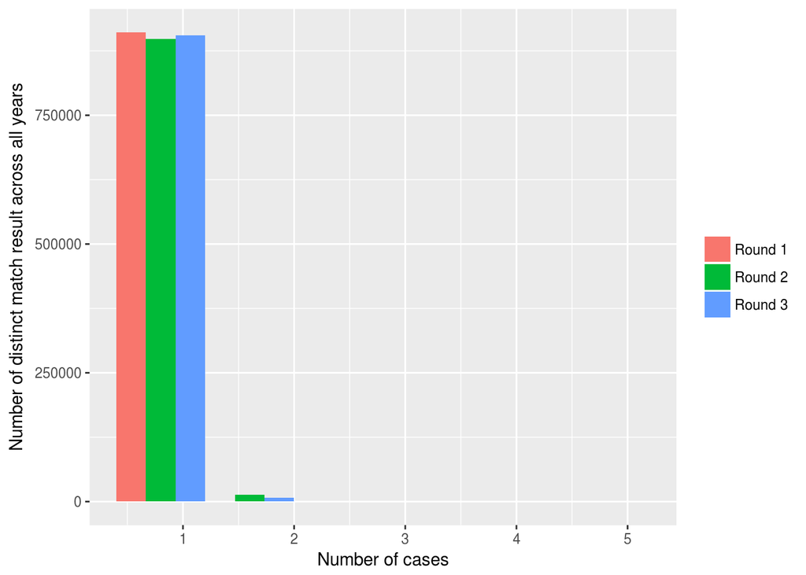

```r
matches <-
  students_with_matches %>%
  group_by(student_id_scram) %>%
  summarize(length(unique(r1match)), length(unique(r2match)), length(unique(r3match))) %>%
  gather("round", "num_unique", 2:4)

matches %>%
  ggplot(aes(x = num_unique, fill=round), alpha = 0.25) +
  geom_histogram(position = "dodge", bins = 6) +
  labs(x = "Number of cases",
       y = "Number of distinct match result across all years",
       fill = "") +
  scale_fill_discrete(labels = c("Round 1", "Round 2", "Round 3"))
```

```r
matches %>%
  group_by(round) %>%
  summarize(frac_1 = sum(num_unique == 1)/n(),
            frac_2 = sum(num_unique == 2)/n(),
            frac_3 = sum(num_unique == 3)/n(),
            frac_4 = sum(num_unique == 4)/n(),
            frac_5 = sum(num_unique == 5)/n())
```

```
## # A tibble: 3 x 6
##                     round    frac_1       frac_2       frac_3       frac_4
##                     <chr>     <dbl>        <dbl>        <dbl>        <dbl>
## 1 length(unique(r1match)) 0.9991108 0.0008892095 0.0000000000 0.000000e+00
## 2 length(unique(r2match)) 0.9854317 0.0142076167 0.0003464738 1.315723e-05
## 3 length(unique(r3match)) 0.9922339 0.0075741794 0.0001776226 1.425367e-05
## # ... with 1 more variables: frac_5 <dbl>
```

### Match result vs. Actual 9th-grade school

Because the lengths of `students_hs` table and of `students_with_matches` table do not match (1,095,091 vs. 932,774), we want to check for duplicates on `student_id_scram`:

```r
duplicate_junebiog <- students_hs %>%
  group_by(student_id_scram) %>%
  count() %>%
  arrange(desc(n)) %>%
  filter(n > 1)
duplicate_junebiog %>%
  select("num_duplicates_over_year" = n, student_id_scram) %>%
  group_by(num_duplicates_over_year) %>%
  summarize(num_students_with_duplicates = n())
```

```
## # A tibble: 7 x 2
##   num_duplicates_over_year num_students_with_duplicates
##                      <int>                        <int>
## 1                        2                        84482
## 2                        3                        30555
## 3                        4                        10059
## 4                        5                         1887
## 5                        6                          359
## 6                        7                           78
## 7                        8                           12
```

Are these numbers so strange? Can there be someone staying in 9th grade over 5,6,7, or even 8 years??

We are trying to drop the `year` column and collapse the duplicates on `student_id_scram` but are unable to. From the error message, we learn that there are 909,427 unique student id’s in this `student_hs` table. Still, that does not match 932,774 the length of `students_with_matches`, hence we will perform duplicate check on this table as well.

Note: we also tried to collapse student id’s in `students_with_matches` (also error!) and learned that there are 912,046 unique student ids’. However, we are hesitant to cast out all the duplicates because some students might re-apply.

```r
# This code does not work and yields error.
# students_hs <-
#   students_hs %>%
#   select(-year) %>%
#   mutate(student_id_scram = unique(student_id_scram)))

duplicate_hsaps <-
  students_with_matches %>%
  group_by(student_id_scram) %>%
  count() %>%
  arrange(desc(n)) %>%
  filter(n > 1)
# students_with_matches %>%
#   filter(student_id_scram %in% c("146472629", "130302023"))
#   arrange(student_id_scram)
summary(duplicate_hsaps)
```

```
##  student_id_scram         n
##  Length:19415       Min.   :2.000
##  Class :character   1st Qu.:2.000
##  Mode  :character   Median :2.000
##                     Mean   :2.068
##                     3rd Qu.:2.000
##                     Max.   :6.000
```

```r
duplicate_hsaps %>%
  select("num_duplicates_over_year" = n, student_id_scram) %>%
  group_by(num_duplicates_over_year) %>%
  summarize(num_students_with_duplicates = n())
```

```
## # A tibble: 5 x 2
##   num_duplicates_over_year num_students_with_duplicates
##                      <int>                        <int>
## 1                        2                        18268
## 2                        3                          998
## 3                        4                          134
## 4                        5                           13
## 5                        6                            2
```

Why did some students re-apply?? The data is supposed to have only 8th grader applying for 9th grade, and 9th graders applying to 10th grades will not be included (see documentation).

The join results in 387,303 rows. This number matches very close to 387,767 the number of instances where `final_disposition_dbn` are not NA’s. However, pay attention to the year differences between the 2 tables - we include a plot of yeardiff distribution.

```r
(nineth_vs_match <-
  inner_join(students_hs, students_with_matches, by=c("student_id_scram")) %>%
  filter(dbn == final_disposition_dbn) %>%
  mutate(yeardiff = year.x - year.y) %>%
  select(year.x, year.y, yeardiff, student_id_scram, dbn, final_disposition_dbn, final_disposition_round, final_disposition))
```

```
## # A tibble: 387,303 x 8
##    year.x year.y yeardiff student_id_scram    dbn final_disposition_dbn
##     <dbl>  <dbl>    <dbl>            <chr>  <chr>                 <chr>
##  1   2008   2009       -1        120022269 27Q475                27Q475
##  2   2010   2009        1        701002000 02M489                02M489
##  3   2010   2009        1        222002000 02M460                02M460
##  4   2010   2009        1        545002000 02M600                02M600
##  5   2010   2009        1        578002000 02M420                02M420
##  6   2010   2009        1        220002100 01M450                01M450
##  7   2010   2009        1        352002100 08X405                08X405
##  8   2010   2009        1        543002100 09X543                09X543
##  9   2010   2009        1        824002100 02M500                02M500
## 10   2010   2009        1        725002100 02M600                02M600
## # ... with 387,293 more rows, and 2 more variables:
## #   final_disposition_round <chr>, final_disposition <chr>
```

```r
summary(nineth_vs_match)
```

```
##      year.x         year.y        yeardiff      student_id_scram
##  Min.   :2008   Min.   :2009   Min.   :-1.000   Length:387303
##  1st Qu.:2011   1st Qu.:2010   1st Qu.: 1.000   Class :character
##  Median :2013   Median :2011   Median : 1.000   Mode  :character
##  Mean   :2013   Mean   :2011   Mean   : 1.124
##  3rd Qu.:2014   3rd Qu.:2013   3rd Qu.: 1.000
##  Max.   :2015   Max.   :2014   Max.   : 6.000
##      dbn            final_disposition_dbn final_disposition_round
##  Length:387303      Length:387303         Length:387303
##  Class :character   Class :character      Class :character
##  Mode  :character   Mode  :character      Mode  :character
##
##
##
##  final_disposition
##  Length:387303
##  Class :character
##  Mode  :character
##
##
##
```

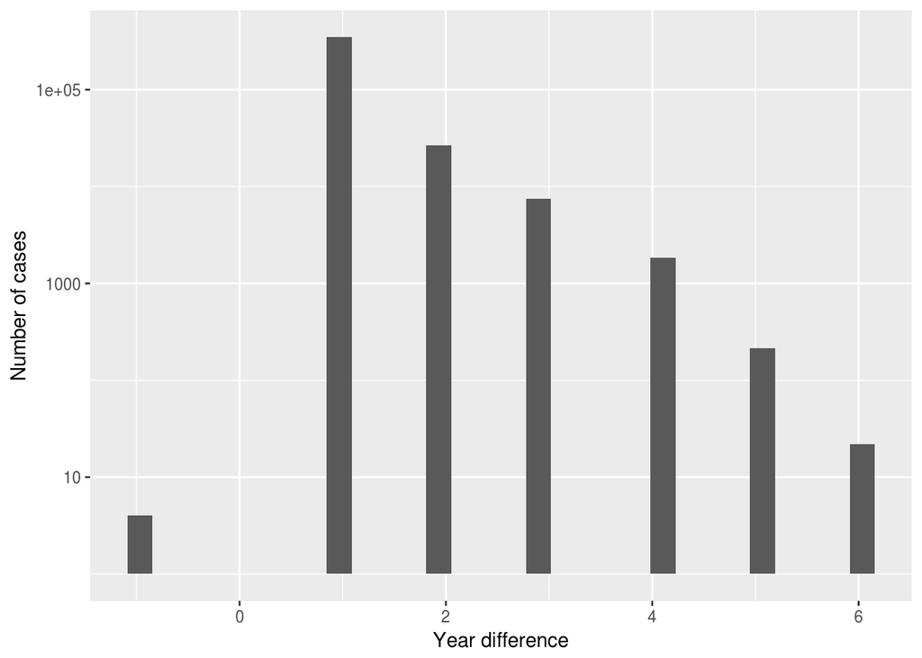

```r
nineth_vs_match$yeardiff %>%
  data.frame() %>%
  ggplot() +
  geom_histogram(aes(x = .)) +
  scale_y_log10("Number of cases", labels = prettyNum) +
  xlab("Year difference")
```

It quite makes sense that the majority of yeardiff values are 1, because you get matched in the fall and June Biog records you with your 9th grade school in the spring of next year. There are 351,105 rows fall into this category.

However, by curiosity, we keep the year value as original in both tables and do the join. There is ONE student returned! How can a student currently in their 9th grade at school X apply for the same school?

```r
(strict_nineth_vs_match <-
  inner_join(students_hs, students_with_matches, by=c("student_id_scram", "year")) %>%
  filter(dbn == final_disposition_dbn) %>%
  select(year, student_id_scram, dbn, final_disposition_dbn, final_disposition_round, final_disposition, r1match:r3match)) %>%
  print(width = Inf)
```

```
## # A tibble: 1 x 9
##    year student_id_scram    dbn final_disposition_dbn final_disposition_round final_disposition r1match r2match r3match
##   <dbl>            <chr>  <chr>                 <chr>                   <chr>             <chr>   <chr>   <chr>   <chr>
## 1  2011        953962624 20K490                20K490                 Round 2              K17Z    <NA>    <NA>    <NA>
```